# withr 2.1.0

Jim Hester

2017-11-15

[withr 2.1.0](http://withr.tidyverse.org/news/index.html) is now available on CRAN! [withr](http://withr.r-lib.org) makes working with global state in R safer and less error prone. It also has no non-base dependencies so is easy to include in packages.

Install the latest version with:

```r
install.packages("withr")
```

# Whither withr?

```r
par("col" = "black")
my_plot <- function(new) {
  old <- par(col = "red", pch = 19)
  plot(mtcars$hp, mtcars$wt)
  par(old)
}
my_plot()
```

```r
par("col")
```

```
#> [1] "black"
```

However one issue when there is an error before you are able to reset the options.

```r
par("col" = "black")
my_plot <- function(new) {
  old <- par(col = "red", pch = 19)
  plot(mtcars$hpp, mtcars$wt)
  par(old)
}
my_plot()
```

```
#> Error in xy.coords(x, y, xlabel, ylabel, log): 'x' and 'y' lengths differ
```

```r
par("col")
```

```
#> [1] "red"
```

Using a base function `on.exit()` is the robust solution to this problem. `on.exit()` will run the resetting code when the block is exited, regardless of it exits normally or with an error.

```r
par("col" = "black")
my_plot <- function(new) {
  old <- par(col = "red", pch = 19)
  on.exit(par(old))
  plot(mtcars$hpp, mtcars$wt)
}
my_plot()
```

```
#> Error in xy.coords(x, y, xlabel, ylabel, log): 'x' and 'y' lengths differ
```

```r
par("col")
```

```
#> [1] "black"
```

[withr](http://withr.r-lib.org) is a solution to these issues. It defines a [large set of functions](http://withr.r-lib.org/#withr---run-code-with-modified-state) for dealing with global settings in R, such as `with_par()`. These functions set one of the global settings for the duration of a block of code, then automatically reset it after the block is completed.

```r
par("col" = "black")
my_plot <- function(new) {
  with_par(list(col = "red", pch = 19),
    plot(mtcars$hp, mtcars$wt)
  )
  par("col")
}
my_plot()
```

```
#> [1] "black"
par("col")
#> [1] "black"
```

In addition to the `with_*` functions there are `local_*` variants whose effects last until the end of the function they are included in. These work similar to `on.exit()`, but you can set the options in one call rather than two.

```r
par("col" = "black")
my_plot <- function(new) {
  local_par(list(col = "red", pch = 19))
  plot(mtcars$hp, mtcars$wt)
}
my_plot()
```

```r
par("col")
```

```
#> [1] "black"
```

# Graphics devices

There are now a comprehensive set of functions to deal with R’s builtin [graphics devices](http://withr.r-lib.org/reference/devices.html).

These functions open a new graphics device, run some code, then automatically close the device. This is very useful when printing multiple plots to the same device.

```r
path <- file.path(Sys.glob("*withr*_files/figure-html"), "test.pdf")
with_pdf(path, width = 7, height = 5, {
  plot(mtcars$hp, mtcars$mpg)
  plot(mtcars$wt, mtcars$mpg)
})
```

[figure not shown]

Thanks to [Richard Cotton’s](https://github.com/richierocks) great [pull request](https://github.com/r-lib/withr/pull/37) for this feature!

## Connections

There are two new functions for cleaning up connections in R. `with_connection()` allows you to automatically close R’s file connections. Here we create a writable file connection, write some lines to it with `with_connection()`, then open a read-only connection and read the file using `local_connection()`.

```r
with_connection(list(con = file("temp", "w")), {
  writeLines(c("foo", "bar"), con)
})
read_temp <- function() {
  con <- local_connection(file("temp", "r"))
  readLines(con)
}
read_temp()
```

```
#> [1] "foo" "bar"
```

`with_db_connection()` provides DBI connections to databases which automatically call `DBI::dbDisconnect()`. Here we create a new [SQLite](https://www.sqlite.org/) database, connect to it with `with_db_connection()`, and write a new table to it. We then create another connection with `local_db_connection()` and read from the table.

```r
db <- tempfile()
with_db_connection(
  list(con = DBI::dbConnect(RSQLite::SQLite(), db)), {
    DBI::dbWriteTable(con, "mtcars", mtcars)
})
head_db_table <- function(...) {
  con <- local_db_connection(DBI::dbConnect(RSQLite::SQLite(), db))
  head(DBI::dbReadTable(con, "mtcars"), ...)
}
head_db_table()
```

```
#>    mpg cyl disp  hp drat    wt  qsec vs am gear carb
#> 1 21.0   6  160 110 3.90 2.620 16.46  0  1    4    4
#> 2 21.0   6  160 110 3.90 2.875 17.02  0  1    4    4
#> 3 22.8   4  108  93 3.85 2.320 18.61  1  1    4    1
#> 4 21.4   6  258 110 3.08 3.215 19.44  1  0    3    1
#> 5 18.7   8  360 175 3.15 3.440 17.02  0  0    3    2
#> 6 18.1   6  225 105 2.76 3.460 20.22  1  0    3    1
```

```r
unlink(db)
```

## Packages

`with_package()` allows you to temporarily attach a package.

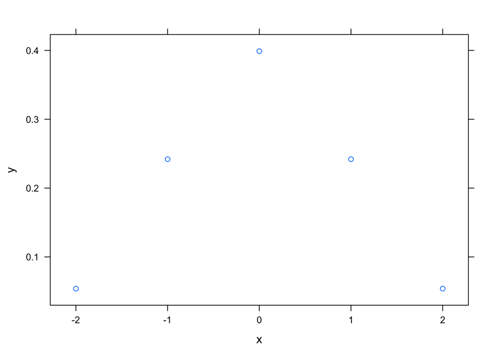

```r
with_package("lattice", {
  xyplot(y ~ x, data.frame(x = -2:2, y = dnorm(-2:2)))
})
```

## Other changes

There are many other bug fixes and other minor improvements in this release. You can see a complete list in the [release notes](https://github.com/tidyverse/withr/releases/tag/v2.1.0).

A big thanks goes to all the community members who contributed code and opened issues since the last release!

[@QuLogic](https://github.com/QuLogic), [@krlmlr](https://github.com/krlmlr), [@hadley](https://github.com/hadley), [@wlandau-lilly](https://github.com/wlandau-lilly), [@jimhester](https://github.com/jimhester), [@kevinushey](https://github.com/kevinushey), and [@richierocks](https://github.com/richierocks)